# 240716_sapflow_workup_v3

PR

2024-07-16

#### Sapflow workup

The goal of this workup is to see if sapflow changed after flooding during the TEMPEST2 flooding events in 2023. To do this, I’m taking data from before, during, and after the flooding events, converting them to Fd, then normalizing them following McDowell et al. 2006 Figure 3.

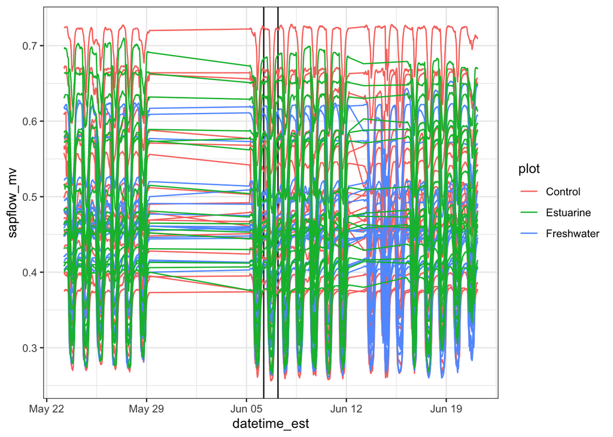

#### Convert raw sapflow to Fd

Once converted to Fd following formulas from Steph/Nate, the data look like this:

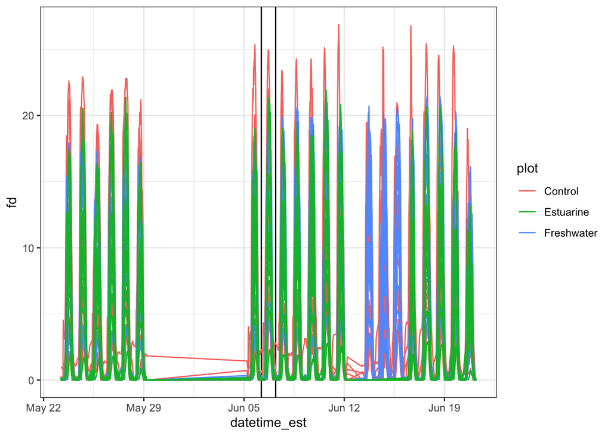

Next, let’s color-code our dataset by time period relative to the flooding events to visualize the portions of the dataset we will be comparing:

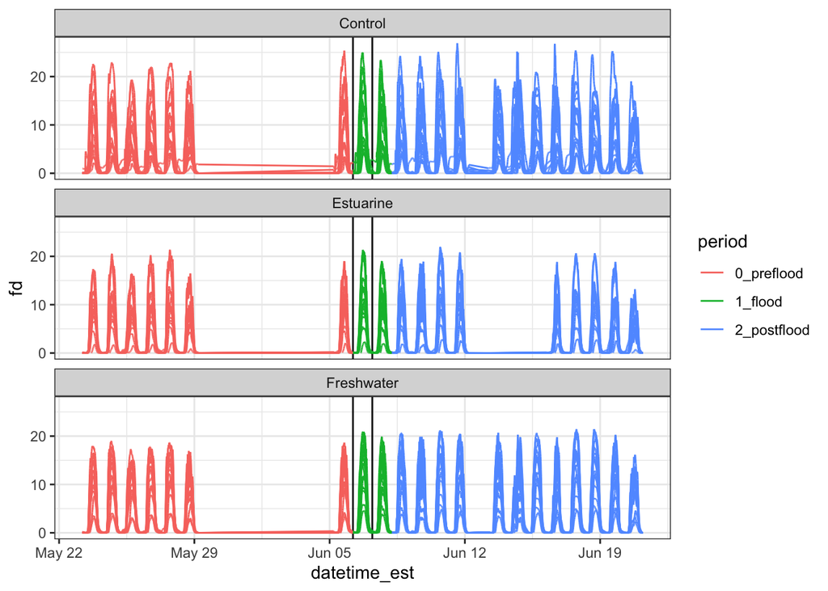

#### Creating means and standard deviations

There seem to be many ways to process these data. Since we are really interested in understanding if there is a change in the treatments relative to the control after flooding, we’ll follow the methods in McDowell et al. 2006 Figure 3. The general steps are

1. normalize each plot to the mean value prior to disturbance, and then
2. normalize treatment plots by date to the Control.

Since our data have different dimensions (i.e., not just one control site), we will do some binning first to simply things. First, let’s trim data to 10am to 2pm to capture maximum sapflow (arbitrary, but centered on noon, happy to change), group by date and plot, and calculate means and standard deviations:

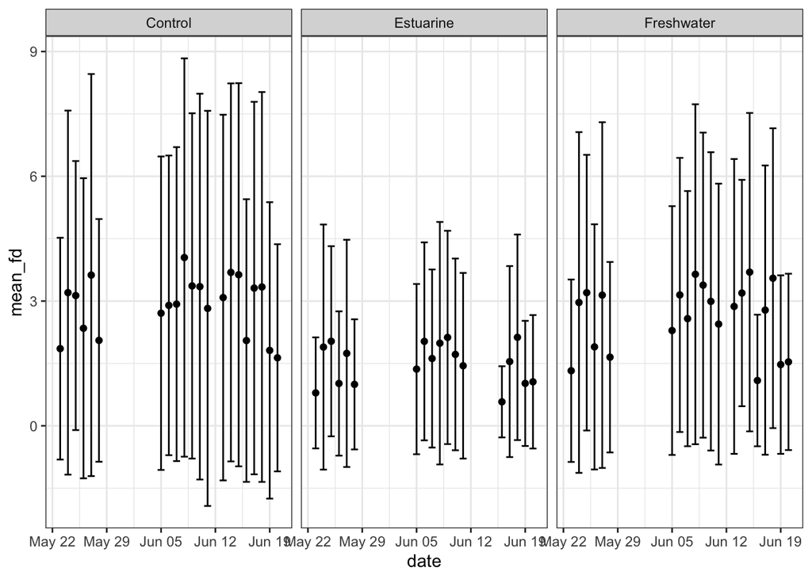

That looks crazy… but let’s power through.

#### Normalize to pre-disturbance (Figure 3B)

The next step is the normalization step #1 above: normalize each plot to the mean of the pre-flood values, basically setting a baseline of 0 for each plot:

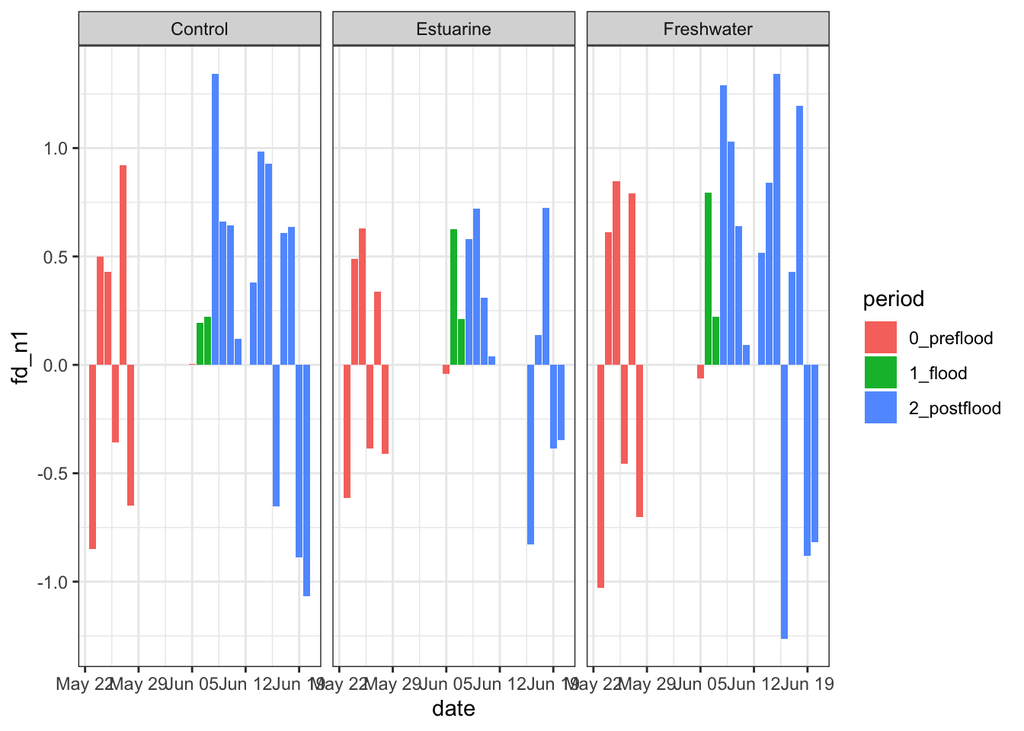

#### Normalize to control plot (Figure 3C)

Now for the second normalization: we’ll subtract the value of Control for each day from the value for each Treatment plot:

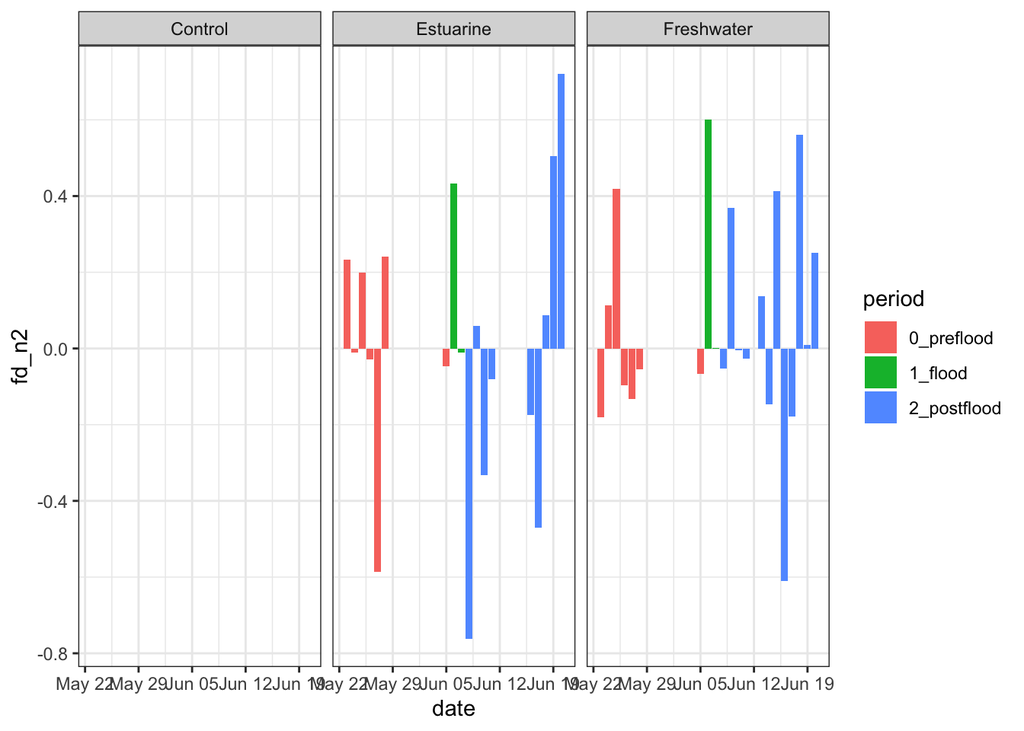

Let’s summarize this a little differently:

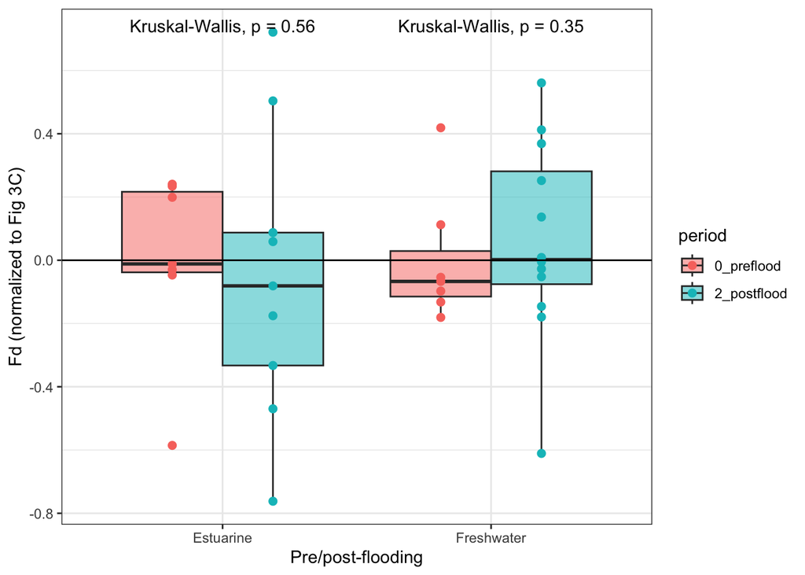

#### Consensus

The p-values above each boxplot suggest that sapflow did not change significantly in either treatment plot in response to flooding.